# 4장 데이터 프레임-Lab3

### Data Frame

- Pandas는 라벨이 붙어있는 2차원 배열(DataFrame)이나 1차원 배열(Series)을 다루는 도구
- 2차원 배열(DataFrame)의 행에 붙어 있는 라벨을 index(인덱스), 열에 붙어 있는 라벨을 column(컬럼)이라 부름
- 1차원 배열에는 행에만 라벨이 붙어 있고, 이를 index(인덱스)라고 부름

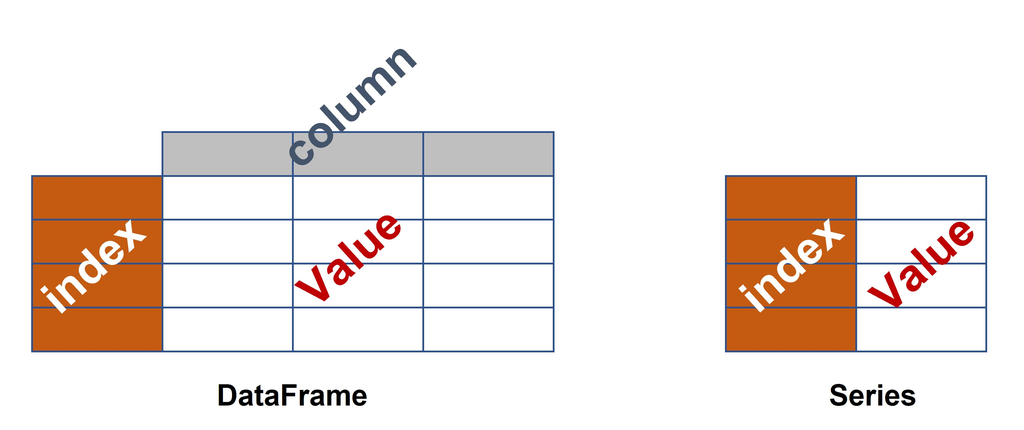

## Lab 3 : 외부 데이터 이용하기

- 분석할 데이터를 엑셀 데이터에서 가져 오기 (https://bit.ly/doit_python)
- pd.read_excel('excel_exam.xlsx')
- 첫번째 행을 컬럼으로 지정하고, 인덱스는 0부터 할당됨
- 특정 컬럼을 인덱스로 만들기 위해서는 set_index() 함수 사용

```python
import pandas as pd
```

```python
# excel 파일 'excel_exam.xlsx'를 읽어들여 DataFrame df_exam으로 저장
df_exam = pd.read_excel('excel_exam.xlsx')
```

```python
# df_exam = pd.read_excel('excel_exam.xlsx', header=3)
```

```python
# DataFrame df_exam의 첫 5개 행을 출력
df_exam.head()
```

|  | id | nclass | math | english | science |
| --- | --- | --- | --- | --- | --- |
| 0 | 1 | 1 | 50 | 98 | 50 |
| 1 | 2 | 1 | 60 | 97 | 60 |
| 2 | 3 | 1 | 45 | 86 | 78 |
| 3 | 4 | 1 | 30 | 98 | 58 |
| 4 | 5 | 2 | 25 | 80 | 65 |

```python
# excel 파일 'excel_exam.xlsx'를 읽어들여 DataFrame df_exam으로 저장
# 단, DataFrame의 index를 'id' 값으로 지정
df_exam = pd.read_excel('excel_exam.xlsx').set_index('id')
```

```python
df_exam.head()
```

| id | nclass | math | english | science |
| --- | --- | --- | --- | --- |
| 1 | 1 | 50 | 98 | 50 |
| 2 | 1 | 60 | 97 | 60 |
| 3 | 1 | 45 | 86 | 78 |
| 4 | 1 | 30 | 98 | 58 |
| 5 | 2 | 25 | 80 | 65 |

> 데이터 분석하기

```python
# 컬럼 math의 합 계산
df_exam['math'].sum()
```

```
1149
```

```python
# df_exam의 행의 개수 확인
len(df_exam)
```

```
20
```

```python
# df_exam의 컬럼별 합 게산
df_exam.sum()
```

```
nclass       60
math       1149
english    1698
science    1189
dtype: int64
```

```python
# df_exam의 컬럼별 평균 게산
df_exam.mean()
```

```
nclass      3.00
math       57.45
english    84.90
science    59.45
dtype: float64
```

## Lab 4 엑셀의 첫번째 행이 변수명(컬럼 이름)이 아닌 경우

```python
# 엑셀 파일의 첫번째 행이 컬럼명이 아님
pd_excel_exam_novar = pd.read_excel('excel_exam_novar.xlsx')
pd_excel_exam_novar.head()
```

|  | 1 | 1.1 | 50 | 98 | 50.1 |
| --- | --- | --- | --- | --- | --- |
| 0 | 2 | 1 | 60 | 97 | 60 |
| 1 | 3 | 2 | 25 | 80 | 65 |
| 2 | 4 | 2 | 50 | 89 | 98 |
| 3 | 5 | 3 | 20 | 98 | 15 |
| 4 | 6 | 3 | 50 | 98 | 45 |

```python
# 엑셀 파일의 첫번째 행이 컬럼명이 아니므로, 컬럼명으로 사용하지 않음
pd_excel_exam_novar = pd.read_excel('excel_exam_novar.xlsx', header = None)
pd_excel_exam_novar.head()
```

|  | 0 | 1 | 2 | 3 | 4 |
| --- | --- | --- | --- | --- | --- |
| 0 | 1 | 1 | 50 | 98 | 50 |
| 1 | 2 | 1 | 60 | 97 | 60 |
| 2 | 3 | 2 | 25 | 80 | 65 |
| 3 | 4 | 2 | 50 | 89 | 98 |
| 4 | 5 | 3 | 20 | 98 | 15 |

```python
# 데이터 프레임 pd_excel_exam_novar의 컬럼명 확인
pd_excel_exam_novar.columns
```

```
Index([0, 1, 2, 3, 4], dtype='int64')
```

```python
# 데이터 프레임 pd_excel_exam_novar의 컬럼명을 별도로 지정함
pd_excel_exam_novar.columns = ['id', 'nclass', 'math', 'english', 'science']
pd_excel_exam_novar.head()
```

|  | id | nclass | math | english | science |
| --- | --- | --- | --- | --- | --- |
| 0 | 1 | 1 | 50 | 98 | 50 |
| 1 | 2 | 1 | 60 | 97 | 60 |
| 2 | 3 | 2 | 25 | 80 | 65 |
| 3 | 4 | 2 | 50 | 89 | 98 |
| 4 | 5 | 3 | 20 | 98 | 15 |

```python
# 데이터 프레임 pd_excel_exam_novar의 index를 컬럼 id로 지정함
pd_excel_exam_novar.set_index('id')
```

| id | nclass | math | english | science |
| --- | --- | --- | --- | --- |
| 1 | 1 | 50 | 98 | 50 |
| 2 | 1 | 60 | 97 | 60 |
| 3 | 2 | 25 | 80 | 65 |
| 4 | 2 | 50 | 89 | 98 |
| 5 | 3 | 20 | 98 | 15 |
| 6 | 3 | 50 | 98 | 45 |
| 7 | 4 | 46 | 98 | 65 |
| 8 | 4 | 48 | 87 | 12 |

## Lab 5 : CSV 파일 불러오기

```python
import pandas as pd
df_exam_csv  = pd.read_csv('exam.csv')
```

```python
df_exam_csv.head()
```

|  | id | nclass | math | english | science |
| --- | --- | --- | --- | --- | --- |
| 0 | 1 | 1 | 50 | 98 | 50 |
| 1 | 2 | 1 | 60 | 97 | 60 |
| 2 | 3 | 1 | 45 | 86 | 78 |
| 3 | 4 | 1 | 30 | 98 | 58 |
| 4 | 5 | 2 | 25 | 80 | 65 |

## 실습

- df_exam에서 math, english, science의 성적인 50점 이상인 학생의 수를 구하시오
- df_exam에서 math의 성적 평균을 구하시오

```python
#
#
```